# Trends in Incarceration (A3)

## Comparison Chart

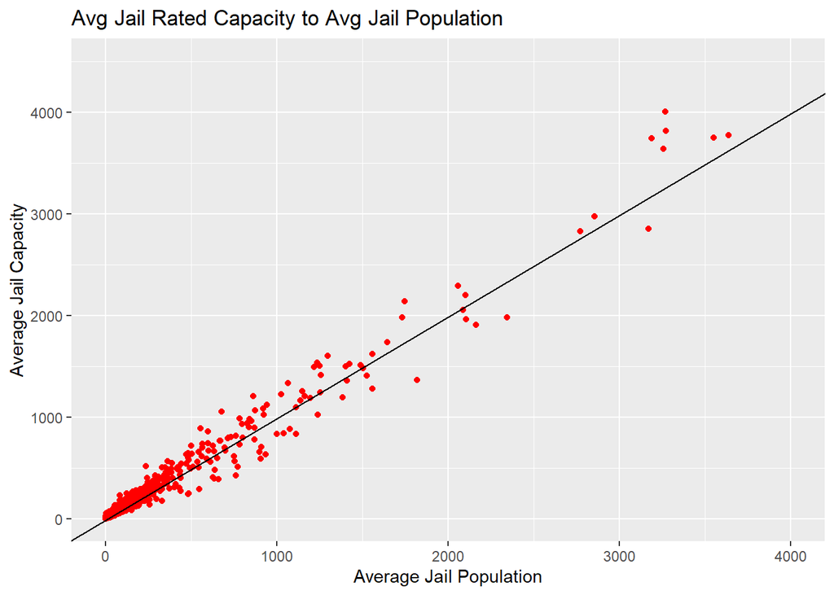

## Map of ICE arrests

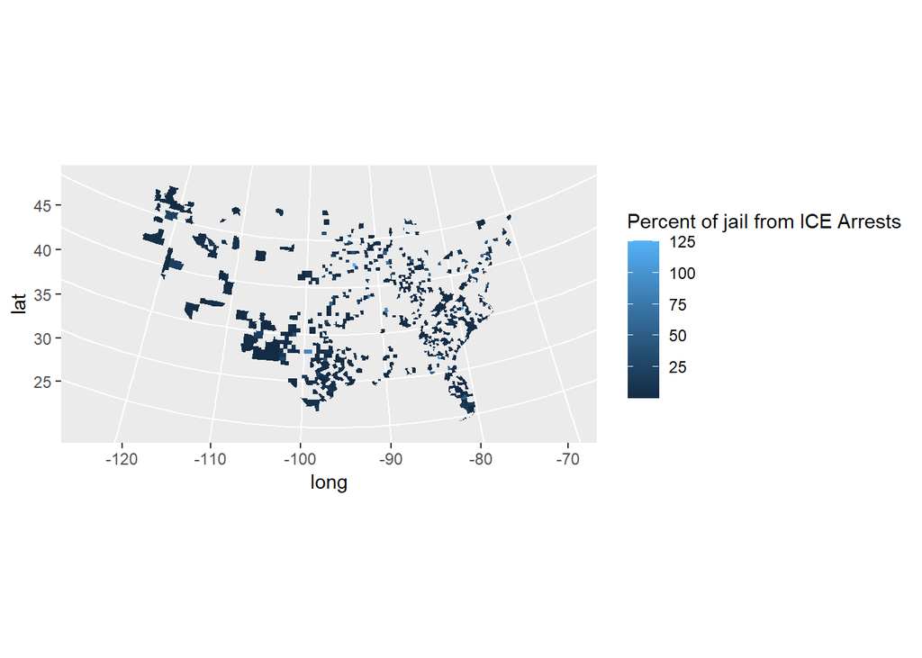

Lastly, in order to see immigration-related arrests as well as where they most frequently, I created a map charting out each county’s ratio of ICE arrests to the total jail population per county.This was achieved using three variables mentioned in the Introduction. What the mapping revealed is consistent with current research and findings. Which is that the most immigrated state to illegally is Texas. This exemplifies yet another fault in our criminal justice system. ICE is a group that exists solely to bust illegal immigrants, and they largely target those near the Mexican border especially in Texas. This is a huge problem, because not only does it encourage law enforcement to arrest people who they think could be illegal immigrants, it perpetuates a power system in which we build a society governed by rules to keep people out of our country by making it hard for them to get visas in the first place, and break up nuclear families already living here who may have arrived illegally.

As was previously stated, the issue of incarceration is complex, we need more thorough amount of data, as well as huge cooperation to identify more concerning trends and solve the solutions to their root problems, but through this report, a high-level understanding and a surface dive can pave the way to future progress.